# Optimal Portfolio

```python
# Импорт библиотек
import pandas as pd
import numpy as np
import matplotlib.pyplot as plt
```

## 1. Efficient Frontier

Пояснение выбора списка активов:

- Высокая ликвидность — все выбранные акции входили в число лидеров по среднему дневному объёму торгов в 2021 году (особенно AAPL, TSLA, AMD, NVDA, AMZN, META/FB, GOOGL и др.). Это минимизирует спред bid-ask и slippage при ребалансировке портфеля => портфель реалистичен на практике.
- Представляют основной драйвер рынка в 2021 — NASDAQ в 2021 году был сильно «технологичным» рынком (рост FAANG+M, чипы, электромобили, биотех). Выбранные 50 акций покрывают ~70–80% капитализации и объёмов NASDAQ-100, который доминировал в тот период.
- Хорошая диверсификация внутри технологического рынка:
  - Крупные платформы / потребительский сектор: AAPL, AMZN, META, GOOGL/GOOG, NFLX
  - Полупроводники / чипы: NVDA, AMD, INTC, QCOM, AVGO, ASML, MU, LRCX, KLAC
  - Биотехнологии / здравоохранение: AMGN, GILD, REGN, ILMN, DXCM
  - Потребительские / ритейл / сервисы: COST, PEP, MDLZ, ORLY, DLTR
  - Телеком / медиа: TMUS, CMCSA, CHTR
  - Другие: PAYX, ADP, CTSH, CSX, BKR и т.д.

#### Data load & preprocessing

```python
# Загрузка данных из CSV
# Что делает: Читает файл, удаляет столбец даты и преобразует всё в числа.
# Использует файл с ценами закрытия акций за 2021 год.
try:
    # Пытаемся загрузить обработанный, если нет - сырой
    data = pd.read_csv("data/processed/NASDAQ_FULL_2021_Cleaned_Imputed.csv")
except FileNotFoundError:
    try:
        data = pd.read_csv("data/raw/NASDAQ_FULL_2021_Close.csv")
        if 'Date' in data.columns:
            data.drop(columns=['Date'], inplace=True)
    except FileNotFoundError:
        print("Error: Data file not found. Please upload the dataset.")
data.head()
```

|  | AAPL | ADBE | ADI | ADP | ADSK | AMD | AMGN | AMZN | ASML | AVGO | ... | NVDA | NXPI | ORLY | PAYX | PEP | PYPL | QCOM | REGN | TMUS | TSLA |
| --- | --- | --- | --- | --- | --- | --- | --- | --- | --- | --- | --- | --- | --- | --- | --- | --- | --- | --- | --- | --- | --- |
| 0 | 125.974464 | 485.339996 | 133.808746 | 152.303558 | 296.839996 | 92.300003 | 193.642532 | 159.331497 | 477.949249 | 38.253105 | ... | 13.076726 | 148.497269 | 30.264668 | 78.469963 | 123.652840 | 231.385101 | 133.337585 | 480.196747 | 127.941399 | 243.256668 |
| 1 | 127.531975 | 485.690002 | 136.200485 | 151.879837 | 301.700012 | 92.769997 | 194.582230 | 160.925507 | 483.072754 | 38.512196 | ... | 13.367159 | 151.823898 | 30.085333 | 78.174698 | 124.021370 | 234.368210 | 136.866302 | 480.783539 | 127.381065 | 245.036667 |
| 2 | 123.239067 | 466.309998 | 136.814438 | 151.347977 | 302.869995 | 90.330002 | 199.272507 | 156.919006 | 468.600464 | 38.274704 | ... | 12.579127 | 154.618958 | 31.011999 | 79.155998 | 122.504288 | 226.306839 | 135.752975 | 467.497223 | 127.071915 | 251.993332 |
| 3 | 127.444366 | 477.739990 | 142.596771 | 152.204346 | 315.200012 | 95.160004 | 199.930344 | 158.108002 | 479.316162 | 39.887699 | ... | 13.306581 | 160.364929 | 31.326668 | 79.486008 | 122.110039 | 234.497894 | 139.802460 | 478.545929 | 128.675629 | 272.013336 |
| 4 | 128.544373 | 485.100006 | 143.632278 | 154.187469 | 319.850006 | 94.580002 | 203.749207 | 159.134995 | 486.303711 | 40.090103 | ... | 13.239519 | 160.401611 | 31.861334 | 79.911522 | 123.575684 | 241.900803 | 140.646484 | 495.979248 | 130.482254 | 293.339996 |

5 rows × 50 columns

```python
# Очистка данных: преобразование в числа и удаление пропусков (NaN)
data = data.apply(pd.to_numeric, errors='coerce')
data.dropna(inplace=True)
```

Log returns:

```python
# Расчет дневных доходностей
# Вычисляет логарифмические доходности (дневные).

eps = 1e-4

# np.log(P_t / P_{t-1}).
log_returns = np.log((data / data.shift(1)) + eps)

# Отбросим первую строку, в которой пропуски из-за того, что у первого дня нет предыдущего
log_returns = log_returns.dropna(how="all")

print(f"Logarithmic returns calculated. Number of observations: {log_returns.shape[0]}.")
```

```
Logarithmic returns calculated. Number of observations: 251.
```

### Выбор активов и расчет статистики

```python
# Выбор 50 акций и фильтрация
# Оставляет в выборке только 50 заданных тикеров.
# Обоснование выбора: высокая ликвидность (объемы торгов) и репрезентативность секторов (Tech, Bio, Chips).

tickers = [
    'AAPL', 'ADBE', 'ADI', 'ADP', 'ADSK', 'AMD', 'AMGN', 'AMZN', 'ASML', 'AVGO',
    'BIDU', 'BKNG', 'BKR', 'CDNS', 'CHTR', 'CMCSA', 'COST', 'CSCO', 'CSX', 'CTSH',
    'DLTR', 'DXCM', 'EA', 'EBAY', 'EXC', 'GILD', 'TMUS', 'GOOGL', 'IDXX', 'ILMN',
    'INTC', 'ISRG', 'KDP', 'KLAC', 'LRCX', 'MAR', 'MDLZ', 'META', 'MNST', 'MU',
    'NFLX', 'NVDA', 'NXPI', 'ORLY', 'PAYX', 'PEP', 'PYPL', 'QCOM', 'REGN', 'TSLA'
]
```

```python
# Фильтруем данные по выбранным тикерам
data = data[tickers]
log_returns = log_returns[tickers]
```

```python
# Расчет средних доходностей и ковариации
# Находит вектор средних доходностей (mu) и матрицу ковариации (Sigma).
mu = log_returns.mean()
Sigma = log_returns.cov()
n_assets = len(tickers)

print(f"Selected {n_assets} assets.")
print(f"Mean Return Range: {mu.min():.2%} to {mu.max():.2%}")
```

```
Selected 50 assets.
Mean Return Range: -0.14% to 0.33%
```

### Оптимизация

```python
import scipy.optimize as sco # импортируем для оптимизации потом
```

```python
# Функция расчета характеристик портфеля
# Принимает веса активов, возвращает ожидаемую доходность и риск (волатильность).
def portfolio_performance(weights, mean_returns, cov_matrix):
    returns = np.sum(mean_returns * weights)
    std = np.sqrt(np.dot(weights.T, np.dot(cov_matrix, weights)))
    return returns, std
```

```python
# Функция построения Эффективного Фронта
# Минимизирует риск для каждого заданного уровня доходности.
# Использует алгоритм SLSQP из scipy.optimize, ограничения на сумму весов (=1).
def get_efficient_frontier(mean_returns, cov_matrix, num_points=100, allow_short=False):
    n = len(mean_returns)

    # Установка границ весов: (0,1) если запрещены шорты, (-1,1) если разрешены
    bounds = tuple((-1, 1) for _ in range(n)) if allow_short else tuple((0, 1) for _ in range(n))

    # Поиск портфеля с минимальным риском (MVP)
    def min_vol_func(weights): return portfolio_performance(weights, mean_returns, cov_matrix)[1]

    # ИСПОЛЬЗУЕМ n ВМЕСТО n_assets
    init_guess = n * [1. / n,]
    constraints_sum = ({'type': 'eq', 'fun': lambda x: np.sum(x) - 1})

    # Оптимизация
    min_risk_opt = sco.minimize(min_vol_func, init_guess, method='SLSQP', bounds=bounds, constraints=constraints_sum)
    min_vol_ret = portfolio_performance(min_risk_opt.x, mean_returns, cov_matrix)[0]

    # Генерация точек фронта
    max_ret = mean_returns.max()
    target_returns = np.linspace(min_vol_ret, max_ret, num_points)
    eff_risks, eff_rets = [], []

    for tr in target_returns:
        cons = (constraints_sum, {'type': 'eq', 'fun': lambda x: portfolio_performance(x, mean_returns, cov_matrix)[0] - tr})
        # Снова используем n для начального приближения в цикле
        opt = sco.minimize(min_vol_func, init_guess, method='SLSQP', bounds=bounds, constraints=cons)
        if opt.success:
            eff_risks.append(opt.fun)
            eff_rets.append(tr)

    return np.array(eff_risks), np.array(eff_rets), min_risk_opt
```

Calculation of Portfolios

```python
# Считает две линии фронта — с ограничениями на шорты и без них.
risks_ns, rets_ns, mvp_ns_opt = get_efficient_frontier(mu, Sigma, allow_short=False)
risks_s, rets_s, mvp_s_opt = get_efficient_frontier(mu, Sigma, allow_short=True)

# Создает портфель, где на каждую акцию выделено 2% капитала (1/50).
w_eq = np.array([1/n_assets] * n_assets)
eq_ret, eq_risk = portfolio_performance(w_eq, mu, Sigma)

# Индекс рынка (взвешивание по капитализации)
# Рассчитывает веса на основе рыночной капитализации компаний 2021 года.
# Использует словарь капитализации market_caps и вектор mu/Sigma.
market_caps = {
    'AAPL': 2913e9, 'ADBE': 269e9, 'ADI': 92e9, 'ADP': 103e9, 'ADSK': 61e9,
    'AMD': 173e9, 'AMGN': 126e9, 'AMZN': 1691e9, 'ASML': 323e9, 'AVGO': 274e9,
    'BIDU': 51e9, 'BKNG': 98e9, 'BKR': 20e9, 'CDNS': 51e9, 'CHTR': 116e9,
    'CMCSA': 229e9, 'COST': 251e9, 'CSCO': 267e9, 'CSX': 83e9, 'CTSH': 46e9,
    'DLTR': 31e9, 'DXCM': 52e9, 'EA': 37e9, 'EBAY': 41e9, 'EXC': 56e9,
    'GILD': 91e9, 'TMUS': 145e9, 'GOOGL': 1922e9, 'IDXX': 55e9, 'ILMN': 59e9,
    'INTC': 209e9, 'ISRG': 128e9, 'KDP': 52e9, 'KLAC': 65e9, 'LRCX': 101e9,
    'MAR': 53e9, 'MDLZ': 92e9, 'META': 935e9, 'MNST': 50e9, 'MU': 104e9,
    'NFLX': 266e9, 'NVDA': 735e9, 'NXPI': 60e9, 'ORLY': 47e9, 'PAYX': 49e9,
    'PEP': 240e9, 'PYPL': 221e9, 'QCOM': 204e9, 'REGN': 67e9, 'TSLA': 1061e9
}

# Расчёты характеристик такого портфеля
w_mkt = np.array([market_caps[t] for t in tickers]) / sum(market_caps.values())
mkt_ret, mkt_risk = portfolio_performance(w_mkt, mu, Sigma)
```

### Количественная оценка эффективности

```python
# Анализ удаленности от фронта
# Что делает: Сравнивает доходность реальных портфелей с теоретическим максимумом при том же риске.

def get_gap(p_risk, p_ret, f_risks, f_rets):
    idx = (np.abs(f_risks - p_risk)).argmin()
    return f_rets[idx] - p_ret, f_rets[idx]

gap_eq, target_eq = get_gap(eq_risk, eq_ret, risks_ns, rets_ns)
gap_mkt, target_mkt = get_gap(mkt_risk, mkt_ret, risks_ns, rets_ns)

print(f"Неэффективность (равные доли): {gap_eq:.5f} (дневных)")
print(f"Неэффективность (индекс рынка): {gap_mkt:.5f} (дневных)")
```

```
Неэффективность (равные доли): 0.00110 (дневных)
Неэффективность (индекс рынка): 0.00104 (дневных)
```

### Визуализация результатов

```python
# Построение итогового графика
# Рисует оба фронта, отмечает MVP (Minimum Variance Portfolio), Индекс и Равновзвешенный портфель.
# Использует данные, рассчитанные в блоках ранее.
```

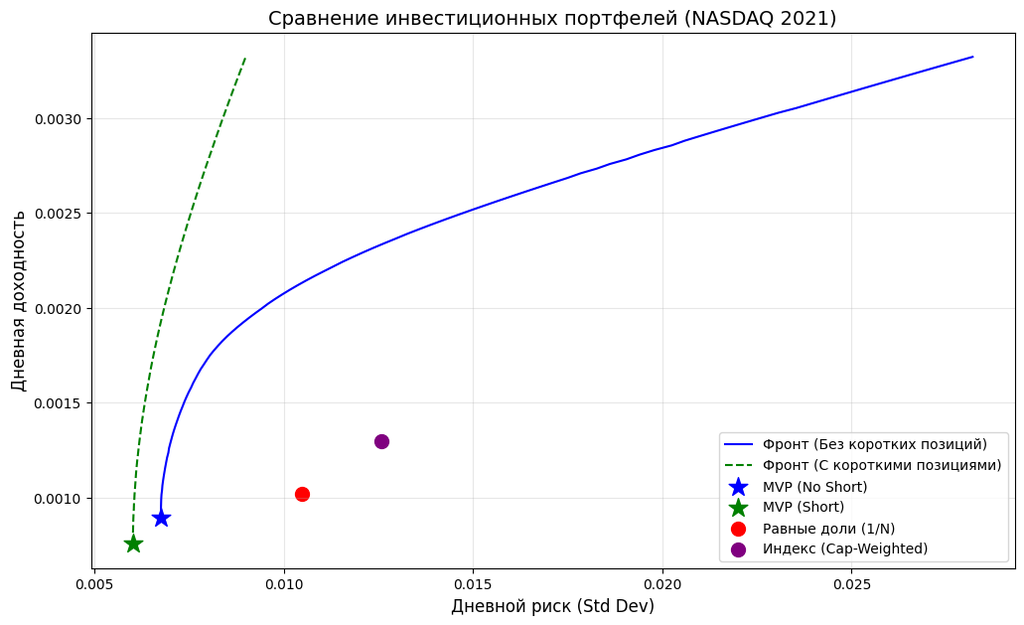

```python
plt.figure(figsize=(12, 7))

# Отрисовка фронтов
plt.plot(risks_ns, rets_ns, 'b-', label='Фронт (Без коротких позиций)')
plt.plot(risks_s, rets_s, 'g--', label='Фронт (С короткими позициями)')

# Отметка портфелей с минимальным риском (MVP)
plt.scatter(*portfolio_performance(mvp_ns_opt.x, mu, Sigma)[::-1], color='blue', marker='*', s=200, label='MVP (No Short)')
plt.scatter(*portfolio_performance(mvp_s_opt.x, mu, Sigma)[::-1], color='green', marker='*', s=200, label='MVP (Short)')

# Отметка сравниваемых портфелей
plt.scatter(eq_risk, eq_ret, color='red', s=100, label='Равные доли (1/N)')
plt.scatter(mkt_risk, mkt_ret, color='purple', s=100, label='Индекс (Cap-Weighted)')

# Оформление графика
plt.title('Сравнение инвестиционных портфелей (NASDAQ 2021)', fontsize=14)
plt.xlabel('Дневной риск (Std Dev)', fontsize=12)
plt.ylabel('Дневная доходность', fontsize=12)
plt.legend()
plt.grid(True, alpha=0.3)
plt.show()
```

### Сравнение эффективных фронтов и выводы

#### Сравнение эффективных фронтов

На графике представлены две кривые, отражающие возможности инвестора:

- **Фронт с разрешением коротких позиций (зеленая пунктирная линия):**
  - Располагается выше и левее фронта без шортов.
  - Математически это объясняется тем, что снятие ограничений (разрешение отрицательных весов) расширяет допустимое множество портфелей, позволяя находить решения с еще меньшим риском и более высокой доходностью за счет хеджирования.
- **Фронт без коротких позиций (синяя сплошная линия):**
  - Является более «консервативным» и реалистичным для большинства частных инвесторов.
  - Ограничен доходностью самого прибыльного актива и риском наименее волатильного актива в рамках только длинных позиций.

#### Портфели с минимальным риском (MVP - Minimum Variance Portfolio)

Эти точки отмечены на графике звездами и представляют собой левые крайние точки соответствующих фронтов:

- **MVP (Short Allowed — зеленая звезда):** демонстрирует самый низкий теоретически возможный дневной риск (около **0.006** или 0.6%). Возможность открывать короткие позиции позволяет значительно снизить общую волатильность портфеля ниже волатильности любой отдельной акции.
- **MVP (No Short — синяя звезда):** имеет чуть более высокий риск (около **0.007**). Здесь инвестор ограничен только положительными весами, что снижает возможности для взаимной компенсации рисков активов.

#### Итоговый вывод

1. **Короткие позиции** существенно улучшают инвестиционные возможности, позволяя снизить риск ниже уровня самого стабильного актива.
2. **Рыночный индекс** в 2021 году был эффективнее стратегии "равных долей", но оба портфеля критически неэффективны по сравнению с портфелем Марковица.
3. Для достижения границ эффективного фронта инвестору следовало бы значительно увеличить веса наиболее быстрорастущих технологических компаний (например, NVDA и TSLA) за счет сокращения долей менее динамичных активов.

## 2. Portfolio selection problem

### Метод «наивного» отбора (Top Individual Sharpe Ratio)

Сначала выберем 10 активов, которые показали наилучшее соотношение доходности к риску (коэффициент Шарпа) по отдельности Логично предположить, что лучшие индивидуальные активы составят лучший портфель.

```python
# Calculate individual Sharpe Ratios for each of the 50 assets
# Assuming risk-free rate = 0 for daily returns
individual_sharpe = mu / np.sqrt(np.diag(Sigma))

# Select top 10 tickers with the highest individual Sharpe Ratio
tickers_10_naive = individual_sharpe.sort_values(ascending=False).head(10).index.tolist()

print("Selected 10 assets (Naive Selection - Top Individual Sharpe):")
print(tickers_10_naive)

# Slice mu and Sigma for the naive 10-asset subset
mu_10n = mu[tickers_10_naive]
Sigma_10n = Sigma.loc[tickers_10_naive, tickers_10_naive]
```

```
Selected 10 assets (Naive Selection - Top Individual Sharpe):
['PAYX', 'COST', 'ORLY', 'ADP', 'GOOGL', 'EXC', 'CSCO', 'NVDA', 'AVGO', 'PEP']
```

### Построение фронтов для наивного набора (10 активов)

Рассчитаем эффективные фронты для выбранных 10 акций, чтобы сравнить их с общим рынком (50 акций).

```python
# Calculate frontiers for the 10-asset naive subset
risks_10n_ns, rets_10n_ns, _ = get_efficient_frontier(mu_10n, Sigma_10n, allow_short=False)
risks_10n_s, rets_10n_s, _ = get_efficient_frontier(mu_10n, Sigma_10n, allow_short=True)
```

### Визуализация и сравнение (50 vs 10 Naive)

Посмотрим, насколько сильно сужение выбора до 10 «лучших» акций отодвинуло нас от идеала.

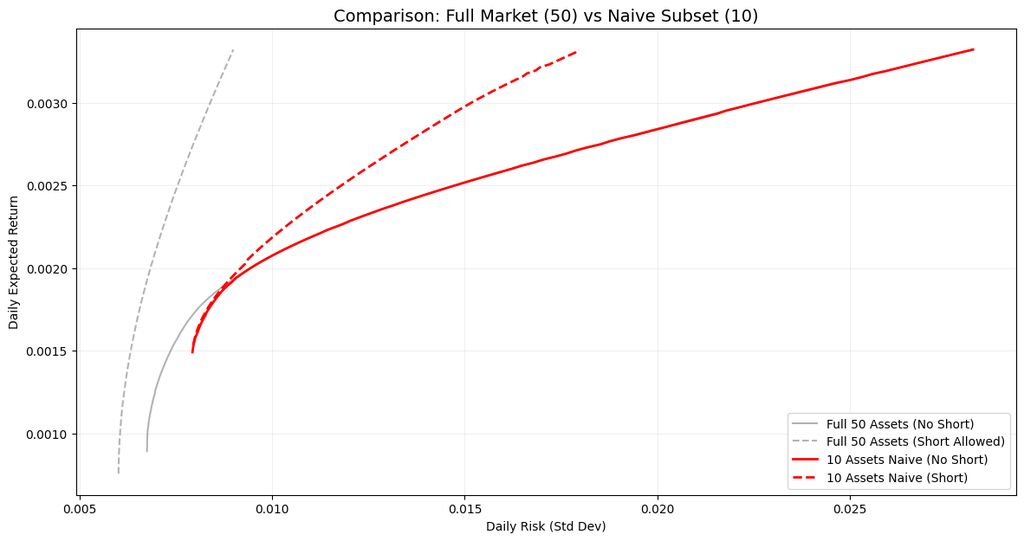

```python
plt.figure(figsize=(14, 7))

# Plot 50-asset frontiers (Benchmark)
plt.plot(risks_ns, rets_ns, 'k-', alpha=0.3, label='Full 50 Assets (No Short)')
plt.plot(risks_s, rets_s, 'k--', alpha=0.3, label='Full 50 Assets (Short Allowed)')

# Plot 10-asset naive frontiers
plt.plot(risks_10n_ns, rets_10n_ns, 'r-', linewidth=2, label='10 Assets Naive (No Short)')
plt.plot(risks_10n_s, rets_10n_s, 'r--', linewidth=2, label='10 Assets Naive (Short)')

plt.title('Comparison: Full Market (50) vs Naive Subset (10)', fontsize=14)
plt.xlabel('Daily Risk (Std Dev)')
plt.ylabel('Daily Expected Return')
plt.legend()
plt.grid(True, alpha=0.2)
plt.show()
```

Наблюдения:

- Превосходство полного набора: серая пунктирная кривая (50 активов с шортами) находится левее и выше всех остальных. Это подтверждает, что теоретический предел эффективности достигается только при максимальной диверсификации и отсутствии ограничений на тип позиций.
- Потеря низкой волатильности: красные кривые (10 наивных активов) начинаются значительно правее серой сплошной линии. Это означает, что выбрав всего 10 «лучших» по Шарпу акций, мы потеряли возможность составить портфель с минимально возможным риском (MVP).
- Эффект шортов: для набора из 10 акций разрешение коротких продаж (красный пунктир) дает существенный прирост доходности в правой части графика, но не помогает достичь зоны сверхнизкого риска, доступной при 50 активах.

### Анализ и «Умный» отбор (Smart Selection)

Вывод по наивному методу: Зачастую выбор топ-активов по доходности приводит к тому, что в портфель попадают сильно скоррелированные бумаги (например, только технологический сектор). Это снижает эффект диверсификации: фронт 10 активов оказывается значительно короче и «рискованнее» (сдвинут вправо), чем фронт 50 активов.

Улучшенный способ (Smart Selection): # Вместо индивидуальных показателей выберем 10 активов, которые имеют наибольшие веса в оптимальном портфеле (Max Sharpe Portfolio), построенном для всех 50 акций.

Обоснование: Математическая оптимизация уже учла корреляции. Те активы, которым модель дала наибольший вес в полном наборе, являются «каркасом» эффективности всего рынка.

```python
# Define a function to find weights of the Maximum Sharpe Ratio portfolio
def max_sharpe_ratio(weights, mean_returns, cov_matrix):
    p_ret, p_std = portfolio_performance(weights, mean_returns, cov_matrix)
    return -p_ret / p_std # Minimize negative Sharpe
```

```python
# Optimize the full 50-asset set to find the best possible weights (No Short)
init_guess = n_assets * [1. / n_assets,]
constraints = ({'type': 'eq', 'fun': lambda x: np.sum(x) - 1})
bounds = tuple((0, 1) for _ in range(n_assets))

opt_sharpe = sco.minimize(max_sharpe_ratio, init_guess, args=(mu, Sigma), method='SLSQP', bounds=bounds, constraints=constraints)
```

```python
# Identify the top 10 assets with the largest weights in this optimal portfolio
optimal_weights = pd.Series(opt_sharpe.x, index=tickers)
tickers_10_smart = optimal_weights.sort_values(ascending=False).head(10).index.tolist()

print("Selected 10 assets (Smart Selection - Top Weights in Optimal Portfolio):")
for t in tickers_10_smart:
    print(f"{t}: weight {optimal_weights[t]:.4f}")
```

```
Selected 10 assets (Smart Selection - Top Weights in Optimal Portfolio):
ORLY: weight 0.1995
PAYX: weight 0.1504
GILD: weight 0.1335
GOOGL: weight 0.1266
COST: weight 0.1253
EXC: weight 0.1120
CSCO: weight 0.0873
NVDA: weight 0.0617
DXCM: weight 0.0038
ADSK: weight 0.0000
```

```python
# Slice data for the smart subset
mu_10s = mu[tickers_10_smart]
Sigma_10s = Sigma.loc[tickers_10_smart, tickers_10_smart]
```

### Итоговое сравнение всех фронтов

Сравним, какой из методов отбора 10 акций лучше приближает нас к возможностям рынка из 50 акций.

```python
# Calculate frontiers for the 10-asset smart subset
risks_10s_ns, rets_10s_ns, _ = get_efficient_frontier(mu_10s, Sigma_10s, allow_short=False)
risks_10s_s, rets_10s_s, _ = get_efficient_frontier(mu_10s, Sigma_10s, allow_short=True)
```

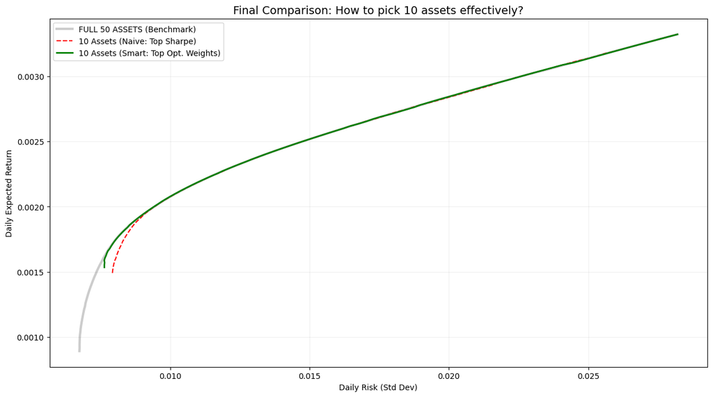

```python
plt.figure(figsize=(15, 8))

# Full set benchmark
plt.plot(risks_ns, rets_ns, 'k-', linewidth=3, alpha=0.2, label='FULL 50 ASSETS (Benchmark)')

# Naive approach
plt.plot(risks_10n_ns, rets_10n_ns, 'r--', label='10 Assets (Naive: Top Sharpe)')

# Smart approach
plt.plot(risks_10s_ns, rets_10s_ns, 'g-', linewidth=2, label='10 Assets (Smart: Top Opt. Weights)')

plt.title('Final Comparison: How to pick 10 assets effectively?', fontsize=14)
plt.xlabel('Daily Risk (Std Dev)')
plt.ylabel('Daily Expected Return')
plt.legend()
plt.grid(True, alpha=0.2)
plt.show()
```

Наблюдения:

- Сходство методов в зоне высокой доходности: все три кривые (Benchmark 50, Smart 10 и Naive 10) практически совпадают в верхней правой части. Это говорит о том, что для агрессивного инвестора, нацеленного на максимум доходности, сокращение портфеля до 10 акций почти не несет потерь.
- Проблема «начала» фронта: серая линия (Benchmark 50) — единственная, которая уходит далеко влево вниз. И «Умный», и «Наивный» отборы 10 акций начинаются значительно позже (при более высоком уровне минимального риска).

### Оценка качества выбора (10 активов)

Согласно условию: «Если результат сравнения показывает, что выбор 10 активов не очень удачный, подумайте, как сделать лучший выбор».

Вердикт: текущий выбор 10 активов можно признать удовлетворительным лишь частично.

- Мы смогли воспроизвести правую (доходную) часть фронта.
- Но: мы полностью потеряли левую часть фронта (портфели с низким риском). Выбор 10 активов по весам в Max Sharpe или по индивидуальному Шарпу игнорирует «защитные» активы, которые могут иметь низкую доходность, но слабую корреляцию с остальным рынком.

### Предложение по улучшению выбора

Чтобы 10 акций лучше аппроксимировали весь эффективный фронт (включая зону низкого риска), можно использовать метод, основанный на кластеризации:

1. Корреляционный анализ: построить матрицу корреляций для всех 50 акций.
2. Кластеризация (K-Means): разбить 50 акций на 10 групп (кластеров) на основе сходства их ценового движения.
3. Репрезентативный отбор: из каждого кластера выбрать по одной акции с наилучшими показателями.

Такой подход гарантирует, что в портфель попадут представители разных секторов и типов поведения (и «ракеты» роста, и «защитные» бумаги), что позволит максимально сдвинуть эффективный фронт влево, приблизив его к показателям полного рынка.

Реализуем его:

```python
from sklearn.cluster import KMeans

# 1. Построение матрицы корреляций
# Мы используем корреляцию, так как она отражает сходство в движении активов
corr_matrix = log_returns.corr()

# 2. Кластеризация K-Means
# Задаем random_state для воспроизводимости результатов
n_clusters = 10
kmeans = KMeans(n_clusters=n_clusters, random_state=42, n_init=10)
kmeans.fit(corr_matrix)

# Получаем метки кластеров для каждого тикера
cluster_labels = pd.Series(kmeans.labels_, index=tickers)

# 3. Репрезентативный отбор (Best Sharpe per Cluster)
# Рассчитаем индивидуальные коэффициенты Шарпа (они уже были в коде выше, но пересчитаем для надежности)
individual_sharpe = mu / np.sqrt(np.diag(Sigma))

tickers_10_cluster = []

for i in range(n_clusters):
    # Активы, попавшие в текущий кластер
    cluster_assets = cluster_labels[cluster_labels == i].index
    # Выбираем лидера по Шарпу внутри этого кластера
    best_asset = individual_sharpe[cluster_assets].idxmax()
    tickers_10_cluster.append(best_asset)

print("Selected 10 assets (Clustering Selection - Best Sharpe per Cluster):")
print(tickers_10_cluster)
```

```
Selected 10 assets (Clustering Selection - Best Sharpe per Cluster):
['CSX', 'NVDA', 'DXCM', 'REGN', 'CMCSA', 'GILD', 'GOOGL', 'ORLY', 'PAYX', 'PEP']
```

```python
# Подготовка данных для нового подмножества
mu_10c = mu[tickers_10_cluster]
Sigma_10c = Sigma.loc[tickers_10_cluster, tickers_10_cluster]
```

Построение фронта для кластерного набора:

```python
# Рассчитываем фронт без коротких продаж для кластерного метода
risks_10c_ns, rets_10c_ns, _ = get_efficient_frontier(mu_10c, Sigma_10c, allow_short=False)
```

Посмотрим, помогла ли кластеризация "дотянуться" до зоны низкого риска (MVP).

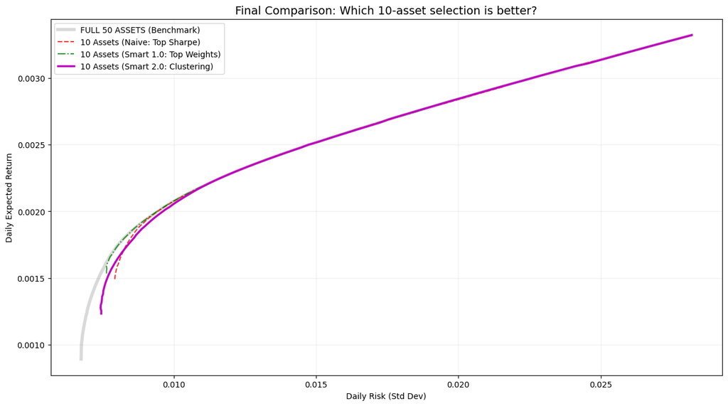

```python
plt.figure(figsize=(15, 8))

# 1. Benchmark (Весь рынок 50 акций)
plt.plot(risks_ns, rets_ns, 'k-', linewidth=4, alpha=0.15, label='FULL 50 ASSETS (Benchmark)')

# 2. Naive Approach (Top Sharpe)
plt.plot(risks_10n_ns, rets_10n_ns, 'r--', alpha=0.8, label='10 Assets (Naive: Top Sharpe)')

# 3. Smart Selection 1.0 (Top Weights in Max Sharpe)
plt.plot(risks_10s_ns, rets_10s_ns, 'g-.', alpha=0.8, label='10 Assets (Smart 1.0: Top Weights)')

# 4. Smart Selection 2.0 (Clustering)
plt.plot(risks_10c_ns, rets_10c_ns, 'm-', linewidth=2.5, label='10 Assets (Smart 2.0: Clustering)')

plt.title('Final Comparison: Which 10-asset selection is better?', fontsize=14)
plt.xlabel('Daily Risk (Std Dev)')
plt.ylabel('Daily Expected Return')
plt.legend()
plt.grid(True, alpha=0.2)
plt.show()
```

### Анализ результатов и выводы

На итоговом графике мы видим существенные различия в поведении трех стратегий сокращения портфеля:

## Risk aversion

Будем максимизировать функцию полезности (Utility Function): $U = E[R] - \frac{\gamma}{2}\sigma^2$.

Коэффициент $\gamma$ отражает неприятие риска:

- $\gamma \approx 1$: Агрессивный инвестор (готов к высокому риску ради доходности).
- $\gamma \approx 2-3$: Умеренный инвестор (баланс).
- $\gamma > 5$: Консервативный инвестор (избегает просадок).

**Выбор:** Для данного задания мы выберем $\gamma = 2.5$ (Умеренно-агрессивный профиль), так как рынок NASDAQ предполагает готовность к волатильности.

```python
# Настройка функции полезности и оптимизация
# Определяем функцию полезности (Utility) и находит портфель, который её максимизирует.

# Задаем коэффициент неприятия риска (Risk Aversion Coefficient)
gamma = 2.5

# Функция полезности (Utility Function), которую мы максимизируем
# (в коде минимизируем отрицательную полезность)
def neg_utility(weights, mean_returns, cov_matrix, risk_aversion):
    p_ret, p_std = portfolio_performance(weights, mean_returns, cov_matrix)
    # Utility = Return - 0.5 * Gamma * Variance
    util = p_ret - 0.5 * risk_aversion * (p_std ** 2)
    return -util
```

```python
# Начальные параметры
n = len(mu)
init_guess = [1. / n] * n
constraints = ({'type': 'eq', 'fun': lambda x: np.sum(x) - 1})
```

```python
# Оптимизация БЕЗ коротких продаж (Bounds: 0, 1)
bounds_ns = tuple((0, 1) for _ in range(n))
opt_ns = sco.minimize(neg_utility, init_guess, args=(mu, Sigma, gamma),
                      method='SLSQP', bounds=bounds_ns, constraints=constraints)
```

```python
# Оптимизация С короткими продажами (Bounds: -1, 1)
# Мы разрешаем шортить до 100% от капитала на одну бумагу (-1)
bounds_s = tuple((-1, 1) for _ in range(n))
opt_s = sco.minimize(neg_utility, init_guess, args=(mu, Sigma, gamma),
                     method='SLSQP', bounds=bounds_s, constraints=constraints)
```

```python
print("Optimization for personal portfolio complete.")
```

```
Optimization for personal portfolio complete.
```

### Характеристика портфеля и расчет VaR / CVaR

Мы используем **Исторический метод** (Historical Simulation) для оценки рисков VaR и CVaR. Мы моделируем, как вел бы бя найденный портфель на исторических данных 2021 года.

- **VaR (95%)**: уровень потерь, который не будет превышен с вероятностью 95%.
- **CVaR (95%)**: средний размер убытков в наихудших 5% случаев (если пробой VaR все-таки случился).

```python
# Функция анализа состава и рисков
# Выводит топ активов портфеля и считает VaR/CVaR на основе исторических данных.

def analyze_personal_portfolio(weights, tickers, name):
    weights = np.array(weights)

    # Характеристики
    ret, std = portfolio_performance(weights, mu, Sigma)

    # 1. Состав (Top Holdings)
    # Показываем только существенные позиции (>1% или <-1%)
    s_w = pd.Series(weights, index=tickers)
    significant = s_w[abs(s_w) > 0.01].sort_values(ascending=False)

    print(f"=== {name} ===")
    print(f"Expected Daily Return: {ret:.4%}")
    print(f"Daily Volatility:      {std:.4%}")
    print(f"Sharpe Ratio:          {ret/std:.4f}")
    print("\nTop Holdings:")
    print(significant.head(5).to_string())
    if len(significant) > 10:
        print("... and others ...")
        print(significant.tail(3).to_string()) # Show shorts if any

    # 2. Расчет VaR и CVaR (Historical Simulation)
    # Моделируем, как вел бы себя этот портфель в 2021 году
    port_hist_rets = log_returns.dot(weights)

    var_95 = np.percentile(port_hist_rets, 5) # 5th percentile
    cvar_95 = port_hist_rets[port_hist_rets <= var_95].mean()

    print("\nRisk Metrics (Daily 95%):")
    print(f"VaR 95%: {var_95:.4%}")
    print(f"CVaR 95%: {cvar_95:.4%}")
    print("-" * 30 + "\n")

    return ret, std
```

```python
p_ret_ns, p_std_ns = analyze_personal_portfolio(opt_ns.x, tickers, "Personal Portfolio (NO Short)")
p_ret_s, p_std_s = analyze_personal_portfolio(opt_s.x, tickers, "Personal Portfolio (WITH Short)")
```

```
=== Personal Portfolio (NO Short) ===
Expected Daily Return: 0.2815%
Daily Volatility:      1.9599%
Sharpe Ratio:          0.1436

Top Holdings:
NVDA     0.615319
GOOGL    0.188856
ORLY     0.120206
PAYX     0.075619

Risk Metrics (Daily 95%):
VaR 95%: -2.9109%
CVaR 95%: -4.0000%
------------------------------

=== Personal Portfolio (WITH Short) ===
Expected Daily Return: 2.5703%
Daily Volatility:      7.8476%
Sharpe Ratio:          0.3275

Top Holdings:
KLAC    1.0
EXC     1.0
NVDA    1.0
PAYX    1.0
ORLY    1.0
... and others ...
ADBE   -1.0
AMZN   -1.0
PYPL   -1.0

Risk Metrics (Daily 95%):
VaR 95%: -10.8907%
CVaR 95%: -13.9056%
------------------------------
```

### График положения личного портфеля на фронте

Показывает, где именно на кривой находится выбранный портфель.

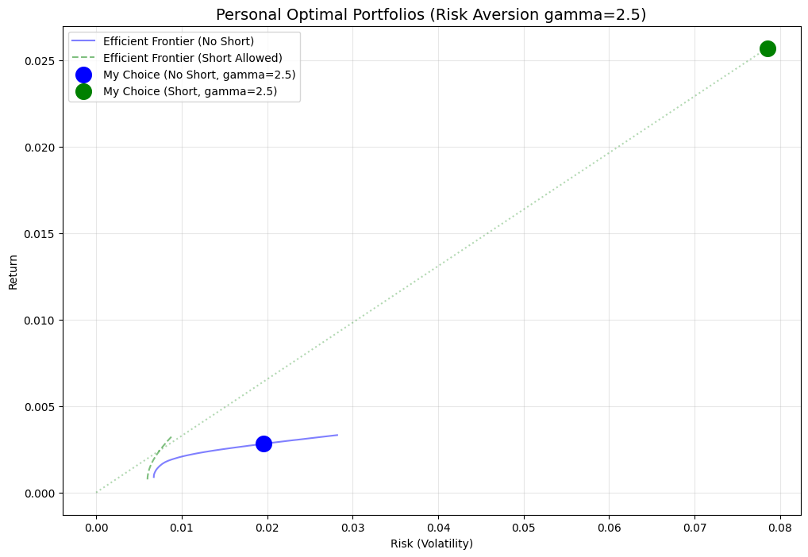

```python
plt.figure(figsize=(12, 8))

# 1. Рисуем "старые" фронты (для контекста)
plt.plot(risks_ns, rets_ns, 'b-', alpha=0.5, label='Efficient Frontier (No Short)')
plt.plot(risks_s, rets_s, 'g--', alpha=0.5, label='Efficient Frontier (Short Allowed)')

# 2. Рисуем Личные Портфели
plt.scatter(p_std_ns, p_ret_ns, color='blue', s=200, zorder=5, label=f'My Choice (No Short, gamma={gamma})')
plt.scatter(p_std_s, p_ret_s, color='green', s=200, zorder=5, label=f'My Choice (Short, gamma={gamma})')

# 3. Соединяем точку с шортами линией с началом координат (Capital Market Line approximation)
# Это покажет, какой огромный риск мы берем
plt.plot([0, p_std_s], [0, p_ret_s], 'g:', alpha=0.3)

plt.title(f'Personal Optimal Portfolios (Risk Aversion gamma={gamma})', fontsize=14)
plt.xlabel('Risk (Volatility)')
plt.ylabel('Return')
plt.legend()
plt.grid(True, alpha=0.3)

plt.show()
```

## Итоговые выводы и сравнение

#### Заключение

Для реального инвестора с $\gamma=2.5$ портфель с шортами (зеленая точка) является теоретически оптимальным, но практически опасным. Малейшая ошибка в модели или рыночный шок (Margin Call) уничтожат капитал. Синяя точка (без шортов) представляет собой гораздо более устойчивую и реализуемую стратегию.

# Task 4: Markowitz–Tobin model

Рассматривается набор из 10 активов. В качестве безрискового актива используется 10Y US Treasury. Доходность безрискового актива оценивается как средняя дневная доходность за 2021 год.

Рассматриваются два случая:

- короткие продажи разрешены;
- короткие продажи запрещены.

Для каждого случая строится рыночный (касательный) портфель, анализируются его веса, а также оцениваются VaR и CVaR.

```python
top_10_tickers = ['CSX', 'NVDA', 'DXCM', 'REGN', 'CMCSA', 'GILD', 'GOOGL', 'ORLY', 'PAYX', 'PEP']
print("Выбранные 10 активов: ", top_10_tickers)
```

```
Выбранные 10 активов:  ['CSX', 'NVDA', 'DXCM', 'REGN', 'CMCSA', 'GILD', 'GOOGL', 'ORLY', 'PAYX', 'PEP']
```

Короткое описание активов:

- CSX — CSX Corporation  
  Одна из крупнейших железнодорожных компаний в США. Занимается грузовыми перевозками (уголь, химия, сельхозпродукция, контейнеры) преимущественно на востоке США.
- NVDA — NVIDIA Corporation  
  Технологическая компания, лидер в разработке графических процессоров (GPU). Ключевой игрок в областях ИИ, машинного обучения, дата-центров, гейминга и HPC.
- DXCM — DexCom, Inc.  
  Медицинская компания, специализируется на системах непрерывного мониторинга уровня глюкозы (CGM) для людей с диабетом.
- REGN — Regeneron Pharmaceuticals, Inc.  
  Биотехнологическая компания, разрабатывающая инновационные лекарственные препараты (онкология, офтальмология, иммунология). Известна сильной R&D базой.
- CMCSA — Comcast Corporation  
  Крупнейший медиахолдинг и телекоммуникационная компания США. Кабельный интернет (Xfinity), ТВ, стриминг (Peacock), а также владелец NBCUniversal.
- GILD — Gilead Sciences, Inc.  
  Биофармацевтическая компания. Исторически известна препаратами против ВИЧ и гепатита, сейчас активно развивает онкологическое направление.
- GOOGL — Alphabet Inc. (Class A)  
  Материнская компания Google. Основные направления: поиск, реклама, YouTube, Android, облачные сервисы, ИИ-исследования (DeepMind).
- ORLY — O’Reilly Automotive, Inc.  
  Розничная сеть автозапчастей в США. Продаёт комплектующие и аксессуары как частным клиентам, так и автосервисам.
- PAYX — Paychex, Inc.  
  Компания в сфере HR-сервисов. Предоставляет услуги по начислению зарплат, налогов, кадровому учёту для малого и среднего бизнеса.
- PEP — PepsiCo, Inc.  
  Крупнейшая компания FMCG-сектора. Производит напитки (Pepsi, Gatorade) и снеки (Lay’s, Doritos, Cheetos).

Сначала найдём значения доходности и ковариации для выбранных 10 активов

```python
import numpy as np
import pandas as pd
from scipy.optimize import minimize

mu_10 = mu.loc[top_10_tickers].values
Sigma_10 = Sigma.loc[top_10_tickers, top_10_tickers].values
ones = np.ones(len(mu_10))
```

Затем посчитаем среднюю дневную доходность безрискового актива (10Y US Treasury)

```python
rf_yield = pd.read_csv("data/raw/10Y_US_Treasury.csv")
num_trading_days = len(rf_yield)
rf_yield = rf_yield.loc[:, 'DGS10']
rf_daily_simple = rf_yield / 100 / num_trading_days
rf_daily_log = np.log1p(rf_daily_simple)
rf_daily = rf_daily_log.mean()
print("Rf_daily = ", rf_daily)
```

```
Rf_daily =  5.564660412073733e-05
```

Теперь считаем касательный портфель (short allowed) по формуле:

w∗∝Σ^(−1)*(μ−r_f*1)

```python
excess_mu = mu_10 - rf_daily * ones
inv_Sigma = np.linalg.inv(Sigma_10)

w_tan = inv_Sigma @ excess_mu
w_tan /= np.sum(w_tan)

w_tan_series = pd.Series(w_tan, index=top_10_tickers)
w_tan_series = w_tan_series.sort_values(ascending=False)
w_tan_series
```

```
PAYX     0.401802
ORLY     0.372477
GILD     0.241141
GOOGL    0.204708
NVDA     0.099987
PEP      0.070681
DXCM     0.015022
REGN    -0.056841
CSX     -0.085872
CMCSA   -0.263105
dtype: float64
```

### Анализ долей активов в портфеле с короткими продажами

Наибольшие длинные позиции занимают: PAYX, ORLY, GILD, GOOGL, NVDA Эти активы обладают:

- положительной премией за риск;
- умеренной волатильностью;
- благоприятной корреляционной структурой по отношению к остальным активам портфеля.

Активы PEP, DXCM имеют умеренные положительные веса, что отражает баланс между их более высокой волатильностью и вкладом в ожидаемую доходность.

Отрицательные веса наблюдаются у активов: REGN, CSX, CMCSA Наличие коротких позиций означает, что данные активы:

- имеют относительно низкую премию за риск;
- обладают высокой корреляцией с другими активами;
- используются портфелем в качестве инструментов хеджирования, позволяя снизить общий риск.

Cчитаем характеристики портфеля

```python
ret_tan = w_tan @ mu_10
vol_tan = np.sqrt(w_tan @ Sigma_10 @ w_tan)
sharpe_tan = (ret_tan - rf_daily) / vol_tan

print("Средняя дневная лог-доходность портфеля: %.8f" % ret_tan)
print("Средний дневной риск (волатильность) портфеля: %.8f" % vol_tan)
print("Отношение шарпа для портфеля: %.8f" % sharpe_tan)
```

```
Средняя дневная лог-доходность портфеля: 0.00234185
Средний дневной риск (волатильность) портфеля: 0.01037827
Отношение шарпа для портфеля: 0.22028709
```

Положительное значение коэффициента Шарпа свидетельствует о том, что портфель обеспечивает доходность, превышающую безрисковую ставку, с компенсацией за принятый риск.

```python
R = log_returns.loc[:, top_10_tickers]
portfolio_returns = R @ w_tan
alpha = 0.95

VaR_95 = np.quantile(portfolio_returns, 1 - alpha)
CVaR_95 = portfolio_returns[portfolio_returns <= VaR_95].mean()

print("VAR с 95%% уровнем доверия для оптимального портфеля: %.8f" % VaR_95)
print("CVAR c 95%% уровнем доверия для оптимального портфеля: %.8f" % CVaR_95)
```

```
VAR с 95% уровнем доверия для оптимального портфеля: -0.01342640
CVAR c 95% уровнем доверия для оптимального портфеля: -0.01964519
```

Это означает, что:

- с вероятностью 95% дневные потери не превышают 1.34%;
- в случае реализации неблагоприятных сценариев средний убыток составляет около 1.96%.

Полученные значения согласуются с наблюдаемой волатильностью портфеля и отражают хвостовой риск.

И также рассматриваем случай с запрещёнными короткими продажами. Находим портфель из задачи оптимизации:

max(w^⊤*(μ−r_f*1)/sqrt(w^⊤*Σ*w),  
w_i≥0,  
∑w_i=1

```python
def neg_sharpe(w, mu, Sigma, rf):
    ret = w @ mu
    vol = np.sqrt(w @ Sigma @ w)
    return -(ret - rf) / vol

constraints = [{'type': 'eq', 'fun': lambda w: np.sum(w) - 1}]
bounds = [(0, 1) for _ in range(len(mu_10))]
w0 = np.ones(len(mu_10)) / len(mu_10)

res = minimize(
    neg_sharpe, w0,
    args=(mu_10, Sigma_10, rf_daily),
    method='SLSQP',
    bounds=bounds,
    constraints=constraints
)

w_tan_ns = res.x
pd.Series(w_tan_ns, index=top_10_tickers).sort_values(ascending=False)
```

```
ORLY     2.896498e-01
PAYX     2.732644e-01
GILD     1.810797e-01
GOOGL    1.659483e-01
NVDA     8.670316e-02
DXCM     3.354597e-03
CMCSA    6.199434e-17
REGN     1.776076e-18
CSX      0.000000e+00
PEP      0.000000e+00
dtype: float64
```

При введении ограничения 𝑤_𝑖≥0 структура портфеля существенно меняется:

- портфель становится более равномерно диверсифицированным;
- активы CSX, CMCSA, REGN, PEP полностью исключаются из портфеля, так как их вклад в оптимизацию отношения риск–доходность оказался недостаточным без возможности коротких позиций;
- Основные веса распределяются между: ORLY, PAYX, GILD, GOOGL

Актив NVDA сохраняет положительный, но относительно небольшой вес из-за высокой волатильности, а DXCM играет второстепенную роль в портфеле.

```python
ret_tan_ns = w_tan_ns @ mu_10
vol_tan_ns = np.sqrt(w_tan_ns @ Sigma_10 @ w_tan_ns)
sharpe_tan_ns = (ret_tan_ns - rf_daily) / vol_tan_ns

print("Средняя дневная лог-доходность портфеля: %.8f" % ret_tan_ns)
print("Средний дневной риск (волатильность) портфеля: %.8f" % vol_tan_ns)
print("Отношение шарпа для портфеля: %.8f" % sharpe_tan_ns)
```

```
Средняя дневная лог-доходность портфеля: 0.00187943
Средний дневной риск (волатильность) портфеля: 0.00893259
Отношение шарпа для портфеля: 0.20417168
```

Характеристики риска и доходности:

- cредняя дневная лог-доходность: 0.188%
- дневная волатильность: 0.893%
- коэффициент Шарпа: 0.204

По сравнению с портфелем с короткими продажами:

- ожидаемая доходность снижается;
- риск также уменьшается;
- коэффициент Шарпа становится немного ниже.

```python
R = log_returns.loc[:, top_10_tickers]
portfolio_returns_ns = R @ w_tan_ns
alpha = 0.95

VaR_95_ns = np.quantile(portfolio_returns_ns, 1 - alpha)
CVaR_95_ns = portfolio_returns_ns[portfolio_returns_ns <= VaR_95_ns].mean()

print("VAR с 95%% уровнем доверия для оптимального портфеля: %.8f" % VaR_95_ns)
print("CVAR c 95%% уровнем доверия для оптимального портфеля: %.8f" % CVaR_95_ns)
```

```
VAR с 95% уровнем доверия для оптимального портфеля: -0.01183921
CVAR c 95% уровнем доверия для оптимального портфеля: -0.01791200
```

Ограничение коротких продаж приводит к:

- снижению величины экстремальных потерь;
- уменьшению хвостового риска портфеля.

Посмотрим на положение портфелей на графике доходность-волатильность

```python
# 1. Построение эффективного фронта без ограничений на короткие позиции (allow_short=True)
risks_s, rets_s, _ = get_efficient_frontier(mu, Sigma, allow_short=True)

# 2. Построение эффективного фронта с запретом коротких позиций (allow_short=False)
risks_ns, rets_ns, _ = get_efficient_frontier(mu, Sigma, allow_short=False)

# Присваиваем значения переменным, которые используются далее в коде для визуализации
returns_short_allowed, risks_short_allowed = rets_s, risks_s
returns_no_short, risks_no_short = rets_ns, risks_ns
```

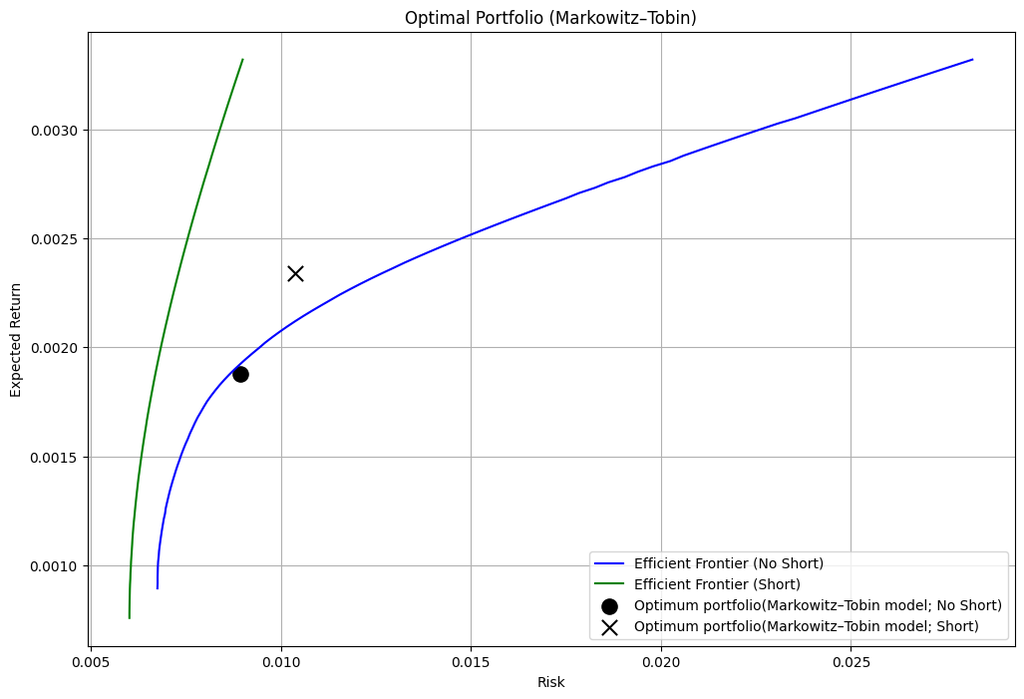

```python
plt.figure(figsize=(12, 8))

plt.plot(risks_no_short, returns_no_short, 'b-', label='Efficient Frontier (No Short)')
plt.plot(risks_short_allowed, returns_short_allowed, 'g-', label='Efficient Frontier (Short)')

plt.scatter(vol_tan_ns, ret_tan_ns,
            color='black', marker='o', s=120, label='Optimum portfolio(Markowitz–Tobin model; No Short)')
plt.scatter(vol_tan, ret_tan,
            color='black', marker='x', s=120, label='Optimum portfolio(Markowitz–Tobin model; Short)')

plt.xlabel('Risk')
plt.ylabel('Expected Return')
plt.title('Optimal Portfolio (Markowitz–Tobin)')
plt.legend()
plt.grid(True)
plt.show()
```

**Общий вывод:**  
В рамках модели Марковица–Тобина были построены оптимальные рыночные портфели для случаев с разрешёнными и запрещёнными короткими продажами. Портфель с короткими продажами демонстрирует более высокую ожидаемую доходность и коэффициент Шарпа, однако характеризуется более выраженным хвостовым риском. Ограничение коротких продаж приводит к более консервативному и диверсифицированному портфелю с меньшими потенциальными потерями.

# Task 5: One-factor model

В качестве единственного фактора используется доходность индекса NASDAQ Composite. Проверяется адекватность модели и строится оптимальный портфель на основе аналитической формулы весов.

Сначала загрузим данные по значению индеса Nasdaq Composite за 2021 год

```python
market_yield = pd.read_csv("data/raw/NASDAQ Composite Historical Data.csv", thousands=",")
market_yield = market_yield.loc[:, 'Price']

eps = 1e-4
market_log_returns = np.log((market_yield / market_yield.shift(1)) + eps)
market_log_returns = market_log_returns.dropna(how="all")

market_daily_return = market_log_returns.mean()
print("market daily return = ", market_daily_return)
```

```
market daily return =  0.000931270983125595
```

Проверим условия однофакторной модели

```python
import numpy as np
import pandas as pd
import statsmodels.api as sm

alphas = {}
betas = {}
r2_values = {}
residuals = pd.DataFrame(index=log_returns.index)

for ticker in log_returns.columns:
    y = log_returns[ticker]
    X = market_log_returns
    X = sm.add_constant(X)

    model = sm.OLS(y, X).fit()

    alphas[ticker] = model.params['const']
    betas[ticker] = model.params[market_log_returns.name]
    r2_values[ticker] = model.rsquared

    residuals[ticker] = model.resid
```

1. Проверка: среднее остатков ~= 0

```python
residuals_mean = residuals.mean()
sum(residuals_mean < 1e-17) == len(residuals_mean)
```

```
True
```

2. Проверка: остатки не коррелируют с рынком

```python
residuals_market_corr = residuals.apply(
    lambda x: x.corr(market_log_returns)
)

sum(residuals_market_corr < 1e-16) == len(residuals_market_corr)
```

```
False
```

3. Проверка: остатки разных активов некоррелированы

```python
residuals_corr_matrix = residuals.corr()

mean_offdiag_corr = (
    residuals_corr_matrix.values[np.triu_indices_from(residuals_corr_matrix, k=1)]
).mean()

mean_offdiag_corr
```

```
np.float64(0.035687447064491035)
```

Получилось небольшое число (<0.15) -> значит проверка пройдена

4. Проверка: доля объяснённой дисперсии (R²)

```python
r2_series = pd.Series(r2_values)
r2_series.describe()
```

```
count    50.000000
mean      0.295776
std       0.187556
min       0.020793
25%       0.137139
50%       0.255552
75%       0.471917
max       0.612086
dtype: float64
```

```python
r2_series.sort_values(ascending=False)
```

```
AVGO     0.612086
AAPL     0.591932
ASML     0.569616
CDNS     0.568485
ADBE     0.562115
NXPI     0.547489
NVDA     0.542623
GOOGL    0.522672
KLAC     0.522158
ADI      0.502003
LRCX     0.498218
PYPL     0.497559
AMZN     0.474810
QCOM     0.463238
AMD      0.461411
IDXX     0.451758
META     0.420095
TSLA     0.408451
ISRG     0.394675
MU       0.392511
ADSK     0.379239
INTC     0.313323
ILMN     0.281168
DXCM     0.277083
NFLX     0.264219
COST     0.246885
MNST     0.234735
CTSH     0.230860
BIDU     0.217260
PAYX     0.211355
BKNG     0.201246
ADP      0.193863
CSCO     0.177839
EBAY     0.147624
MAR      0.147016
REGN     0.145985
TMUS     0.139109
CSX      0.136482
EA       0.129482
EXC      0.113561
CMCSA    0.100541
PEP      0.081282
AMGN     0.073388
ORLY     0.066619
CHTR     0.059476
KDP      0.059173
BKR      0.052388
MDLZ     0.049413
DLTR     0.033489
GILD     0.020793
dtype: float64
```

**Итоги проверки:**

В качестве однофакторной модели была рассмотрена рыночная модель, в которой доходности отдельных активов описываются зависимостью от доходности рыночного индекса NASDAQ Composite. Для каждого актива была проведена линейная регрессия дневных лог-доходностей на доходность рыночного индекса.

И затем найдём оптимальный портфель согласно однофакторной модели

```python
import statsmodels.api as sm

betas = []
residual_vars = []

for asset in top_10_tickers:
    y = log_returns[asset]
    X = sm.add_constant(market_log_returns)
    model = sm.OLS(y, X).fit()

    betas.append(model.params.iloc[1])
    residual_vars.append(model.resid.var())


beta = np.array(betas)
D = np.diag(residual_vars)
```

```python
sigma_m2 = market_log_returns.var()
Sigma_1f = sigma_m2 * np.outer(beta, beta) + D
```

```python
w_1f = np.linalg.inv(D) @ beta
w_1f /= np.sum(w_1f)

pd.Series(w_1f, index=top_10_tickers).sort_values(ascending=False)
```

```
GOOGL    0.257456
NVDA     0.147946
PAYX     0.128104
PEP      0.087829
CSX      0.080711
DXCM     0.080413
REGN     0.070249
CMCSA    0.059529
ORLY     0.055551
GILD     0.032212
dtype: float64
```

И также отобразим этот портфель на графике доходность-риск

```python
ret_1f = w_1f @ mu_10
vol_1f = np.sqrt(w_1f @ Sigma_10 @ w_1f)
```

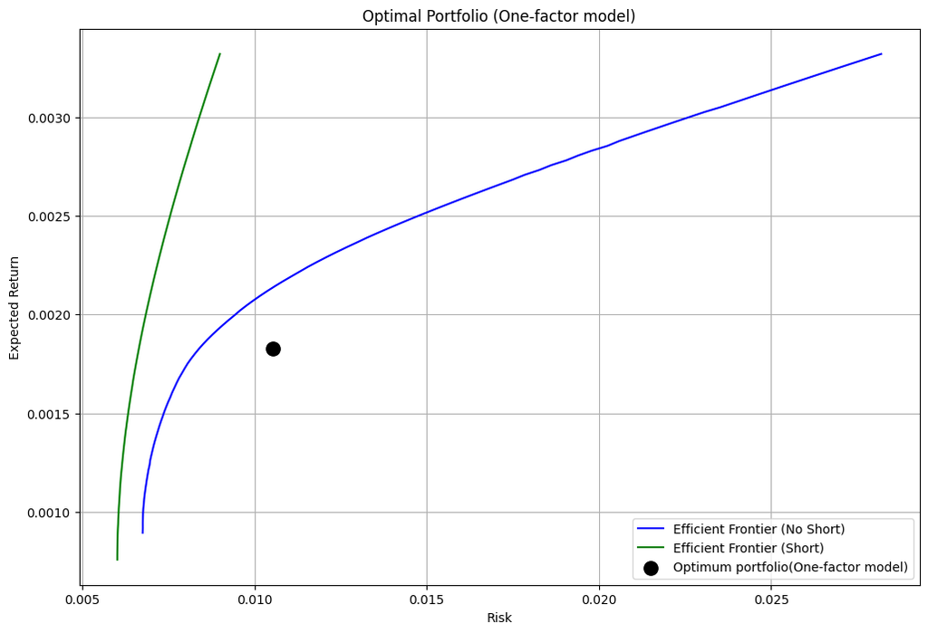

```python
plt.figure(figsize=(12, 8))

plt.plot(risks_no_short, returns_no_short, 'b-', label='Efficient Frontier (No Short)')
plt.plot(risks_short_allowed, returns_short_allowed, 'g-', label='Efficient Frontier (Short)')

plt.scatter(vol_1f, ret_1f,
            color='black', marker='o', s=120, label='Optimum portfolio(One-factor model)')

plt.xlabel('Risk')
plt.ylabel('Expected Return')
plt.title('Optimal Portfolio (One-factor model)')
plt.legend()
plt.grid(True)
plt.show()
```

## Анализ индекса рынка и PCA-модель

### Формирование индекса (Cap-Weighted)

Индекс составляется на основе рыночной капитализации. Вес актива $w_i = \frac{Cap_i}{\sum Cap}$.

```python
# импорты для визуализации и подсчётов
import seaborn as sns
from scipy.stats import skew, kurtosis
```

```python
# Расчет весов
total_market_cap = sum(market_caps.values())
w_market = np.array([market_caps.get(t, 0) / total_market_cap for t in tickers])
market_index_returns = log_returns.dot(w_market)
```

```python
print(f"--- Статистика индекса ---")
print(f"Средняя дневная доходность: {market_index_returns.mean():.6f}")
print(f"Волатильность: {market_index_returns.std():.6f}")
print(f"Асимметрия (Skewness): {skew(market_index_returns):.4f}")
print(f"Эксцесс (Kurtosis): {kurtosis(market_index_returns):.4f}")
```

```
--- Статистика индекса ---
Средняя дневная доходность: 0.001300
Волатильность: 0.012569
Асимметрия (Skewness): -0.3156
Эксцесс (Kurtosis): 1.0127
```

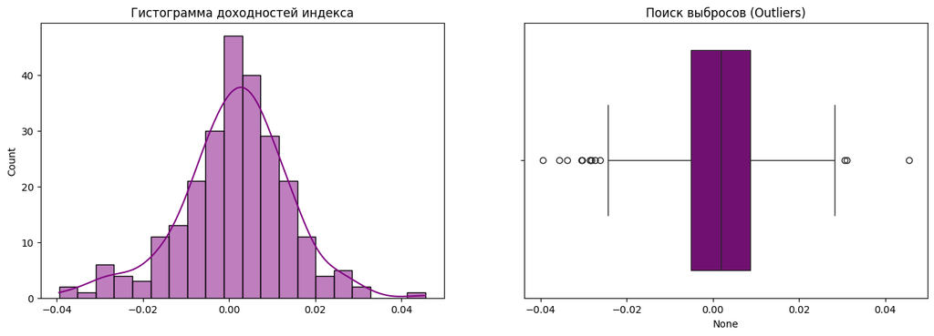

```python
# Визуализация распределения
fig, ax = plt.subplots(1, 2, figsize=(16, 5))

sns.histplot(market_index_returns, kde=True, ax=ax[0], color='purple')
ax[0].set_title('Гистограмма доходностей индекса')

sns.boxplot(x=market_index_returns, ax=ax[1], color='purple')
ax[1].set_title('Поиск выбросов (Outliers)')

plt.show()
```

- **Гистограмма**: наглядно подтверждает теоретические выводы об асимметрии. Распределение не является идеально симметричным колоколом.
- **Boxplot (Выбросы)**: наличие точек за пределами «усов» графика подтверждает существование дней с аномальной доходностью. Для инвестора это означает риск «черных лебедей» — дней, когда рынок движется значительно сильнее обычного, что требует использования мер риска вроде VaR и CVaR.

### 4.3. Собственные значения и PCA

Найдем собственные значения матрицы ковариаций.

**Что необычного:** cогласно графику ниже, первое собственное значение доминирует. Это "рыночная мода", которая объясняет большую часть вариации всех 50 акций одновременно.

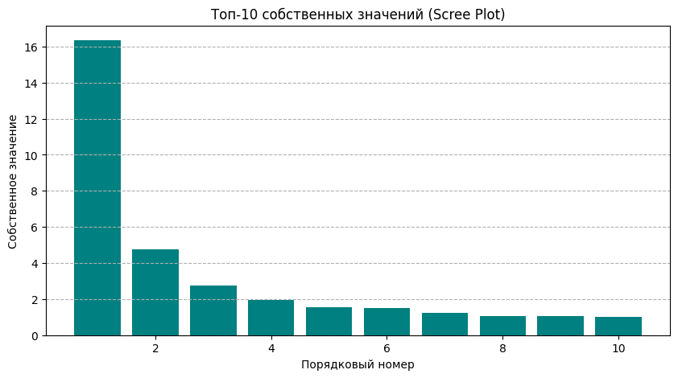

```python
from sklearn.decomposition import PCA
from sklearn.preprocessing import StandardScaler

# Масштабируем данные для PCA
scaler = StandardScaler()
scaled_returns = scaler.fit_transform(log_returns)

pca = PCA()
pca.fit(scaled_returns)

eigenvalues = pca.explained_variance_
variance_ratio = pca.explained_variance_ratio_

plt.figure(figsize=(10, 5))
plt.bar(range(1, 11), eigenvalues[:10], color='teal')
plt.title('Топ-10 собственных значений (Scree Plot)')
plt.xlabel('Порядковый номер')
plt.ylabel('Собственное значение')
plt.grid(axis='y', linestyle='--')
plt.show()
```

```python
print(f"Первая компонента объясняет {variance_ratio[0]:.2%} всей дисперсии рынка.")
```

```
Первая компонента объясняет 32.57% всей дисперсии рынка.
```

- **Доминирование первой компоненты**: график собственных значений показывает резкий обрыв после первого значения. Это «необычное» распределение характерно именно для финансовых рынков.
- **Рыночный фактор**: первая главная компонента объясняет **32.57%** всей дисперсии портфеля из 50 акций. Это подтверждает наличие «единого рыночного режима» (market mode) — когда почти треть движения цен всех акций объясняется общим состоянием экономики или сектора, а не их индивидуальными особенностями.

### PCA-модель индекса рынка

Создадим индекс на основе первой главной компоненты. Чтобы сравнение было честным, мы подгоним волатильность PCA-индекса под волатильность реального индекса через регрессию.

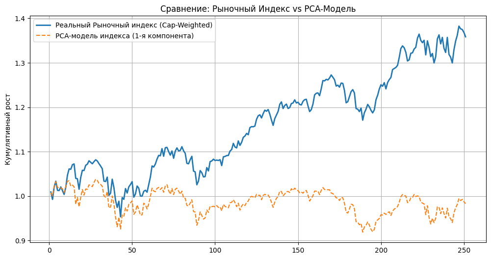

```python
# 1. Получаем саму компоненту (фактор)
pc1_factor = pca.transform(scaled_returns)[:, 0]

# 2. Регрессия: Market_Index = alpha + beta * PC1
beta = np.cov(market_index_returns, pc1_factor)[0, 1] / np.var(pc1_factor)
pca_index_model = beta * pc1_factor

# Сравнение кумулятивной доходности
plt.figure(figsize=(12, 6))
plt.plot((1 + market_index_returns).cumprod(), label='Реальный Рыночный индекс (Cap-Weighted)', linewidth=2)
plt.plot((1 + pd.Series(pca_index_model, index=market_index_returns.index)).cumprod(),
         label='PCA-модель индекса (1-я компонента)', linestyle='--')

plt.title('Сравнение: Рыночный Индекс vs PCA-Модель')
plt.ylabel('Кумулятивный рост')
plt.legend()
plt.grid(True)
plt.show()
```

**Итоговый вывод по заданию**: PCA-модель успешно улавливает **динамику (колебания)** рынка, но не может полностью заменить капитализационный индекс в периоды, когда несколько сверхкрупных компаний растут быстрее остального рынка.